# 데이터시각화

## 1. 데이터 스토리텔링

- 데이터로 스토리를 전달하기 위한 방법
  1. 해당 상황 정보를 이해한다.
  2. 적합한 시각적 디스플레이를 선택한다.
  3. 불필요한 요소를 제거한다.
  4. 여러분이 원하는 위치에 주목을 이끌어낸다.

  *인간은 ‘Z’ 모양으로 정보를 인지하니 왼쪽 상단에 중요한 정보를 기입하면 좋겠죠.*
  5. 설계자처럼 생각한다.
  6. 스토리를 전달한다.
  7. 종합학습 및 사례연구

### 1.1 상황 정보의 중요성

- 소통하는 대상이 누구인가 ?
- 청중이 알고자 하는 것이 무엇인가?
- 핵심포인트를 말하고자할 때 어떤 데이터를 활용할 것인가?
1. 대상

   ```
   - 청중: 청중의 범위를 좁히기 위해 `의사결정권자`가 누구인지 알아내라 !

   - 발표자
   ```

2. 주제

   ```
   - 실행

   - 매커니즘: 청중과 어떻게 의사소통을 할 것인가?

   - 어조: 가벼운 주제인가 또는 심각한 주제인가?
   ```

3. 방법

   ```
   - 청중이 누군지 무엇을 알려주고 싶은지 명확하게 정리하는 것.
   ```

### 1.2 통찰력이 있는 발표가 되기 위해 필요한 핵심조건

```
    - 성공적인 결과는 어떤 모습인가?

    - 한문장으로 말해야 한다면 무엇을 말할 것인가?
```

### 1.3 빅아이디어 & 3분 스토리

- 3분 스토리: 청중이 무엇을 알아야 하는지를 알아야만 스토리를 명확히 하고 문서화 할 수 있음.
- 빅아이디어: 3분 스토리를 한, 두문장으로 더 축약한 것이다.
  - 나만의 관점을 문서화해야 한다.
  - 핵심을 전달해야 한다.
  - 완전한 문장이어야 한다.

### 1.4 스토리보딩

- 발표를 구성하는 것. 발표하려는 내용을 시각화한 개략적인 내용. pricet작업 전 포스트잇, 화이트 보드 를 사용해 발표내용 정리.

**3분 스토리 실습**

1. 대상: 청중을 정하시오.
2. 주제: 여러분이 청중에게 전달하고자 하는 구체적인 주제를 정하시오.
3. 방법: 청중이 누구이며, 전달하고자 하는 스토리에 대한 입증자료로 활용 가능한 데이터가 무엇인지 생각해 보시오.
4. 3분 스토리를 만든다.

## 2. 효과적인 시각화 자료 선택

- 간단한 텍스트 : 공유하고자 하는 숫자가 한 두개일 때. 청중의 주목을 이끌어냄.

**ggplot2 패키지를 사용하기에 앞서.**

-ggplot2의 문법을 구성하는 기본 요소는 아래와 같다.

```
- 데이터 프레임(data frame)
- 색상, 크기 같은 외적 요소(aes)
- 점, 선, 모양 같은 기하학적 요소(geoms)
- 통계적 처리 방법(stats)
- aes에서 사용할 스케일(scale)
```

### 2.1 산점도

- 두 변수가 어떤 관계가 있는지 여부를 알아내기 위해.

```r
# 범주의 정렬을 위한 팁. (from Mr.cho)
a<-data.frame(price=c(2400,3500,4800,1200,1250,1600,2000), week=c('금','토','일','월','화','수','목'))
a$week <- factor(a$week)
a$week<- factor(a$week, levels =c('월','화','수','목','금','토','일') )  # factor 함수 내에서 levels의 순서를 원하는 순서대로 정해준다.
arrange(a, week) # 데이터 프레임을 정렬
```

| price | week |
| --- | --- |
| 1200 | 월 |
| 1250 | 화 |
| 1600 | 수 |
| 2000 | 목 |
| 2400 | 금 |
| 3500 | 토 |
| 4800 | 일 |

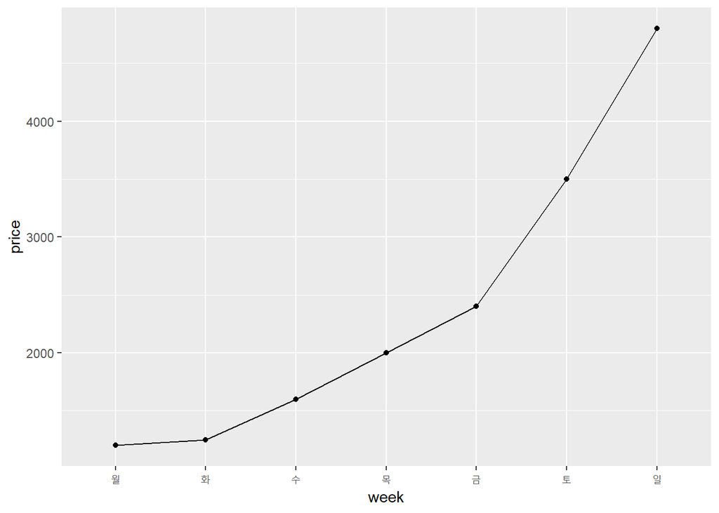

```r
# 산점도 그리기
ggplot(a,aes(week,price)) + geom_point() + geom_line(aes(group=1))
```

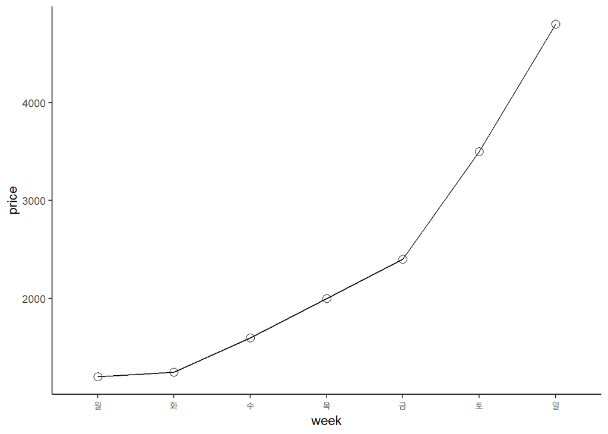

```r
ggplot(a,aes(week,price))+geom_point(shape=1,aes(x=week, y=price),size=3)+theme(panel.background = element_blank(), axis.line = element_line(colour = "black"))+geom_line(aes(group=1))
```

```r
#ggplot(데이터프레임, aes(x축, y축)) + geom_point(포인트 옵션) + theme(그래프 디자인 설정) + geom_line(각 범주내 데이터가 1개 뿐이므로 aes(group=1) 설정을 하여 값들을 연결.)
```

### 2.2 테이블

- 더 많은 데이터를 보여줘야 할 때.
- 청중이 특별한 행을 살펴봐야하는 경우.
- 테이블의 가독성을 개선하기 위해 경계선을 회색으로 설정하거나 모두 제거하는 방안이 효과적임.

### 2.3 히트맵

- 테이블 형태로 데이터를 시각화함.
- 셀의 배경색으로 해당 정보를 표시.
- 색의 채도를 이용.

```r
#1. 데이터 생성
# expand.grid()함수는 원소들의 곱집합(cartesian product)의 형태로 데이터 프레임 생성할 수 있게 해준다.
df.team_data <- expand.grid(teams = c("Team A", "Team B", "Team C", "Team D")
                            ,metrics = c("Metric 1", "Metric 2", "Metric 3", "Metric 4", "Metric 5")
)
df.team_data$performance <- rnorm(nrow(df.team_data))
df.team_data
```

| teams | metrics | performance |
| --- | --- | --- |
| Team A | Metric 1 | -0.2109963 |
| Team B | Metric 1 | -0.6313695 |
| Team C | Metric 1 | -1.2207458 |
| Team D | Metric 1 | -0.4432065 |
| Team A | Metric 2 | 0.2425638 |
| Team B | Metric 2 | -0.5358392 |
| Team C | Metric 2 | 0.5921684 |
| Team D | Metric 2 | 1.0336810 |
| Team A | Metric 3 | -0.1637573 |
| Team B | Metric 3 | 1.7456998 |

[output cut: 10 more lines]

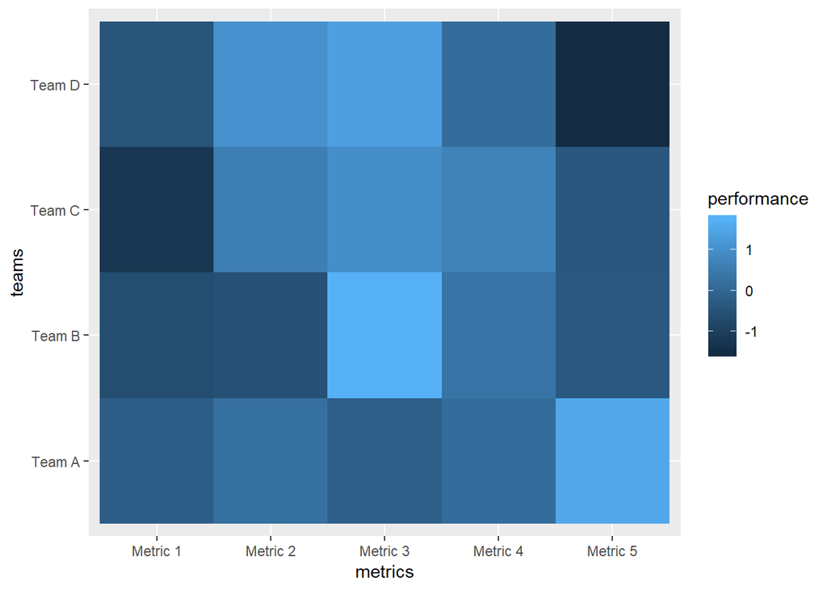

```r
#2. ggplot의 geom_tile()함수를 활용하여 히트맵 그래프 그리기
ggplot(data = df.team_data, aes(metrics, teams)) + geom_tile(aes(fill=performance))
```

### 2.4 선그래프

- 연속형 데이터를 그리기 위해 사용.
- 요약 통계값을 수평선으로 표시.
- 해당 범위를 시각화하여 의미 부여.

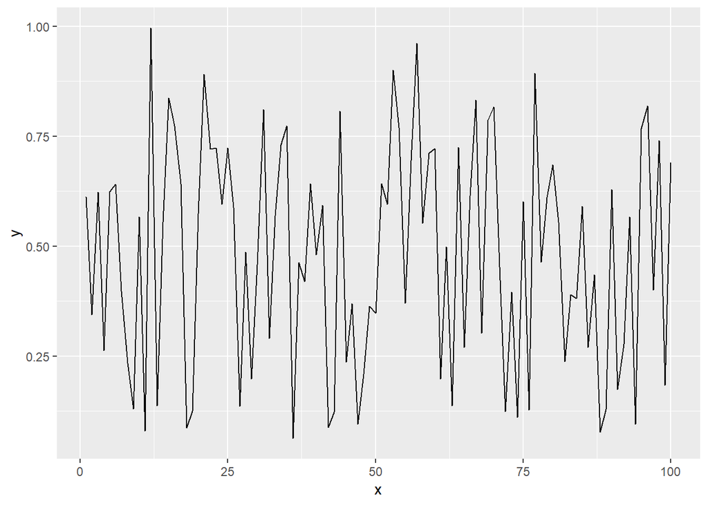

```r
r <- data.frame(x=c(1:100), y=runif(100,0,1))
ggplot(r, aes(x,y)) + geom_line() # 범주가 아닌 경우 geom_line()에 별다른 옵션이 필요하지 않다.
```

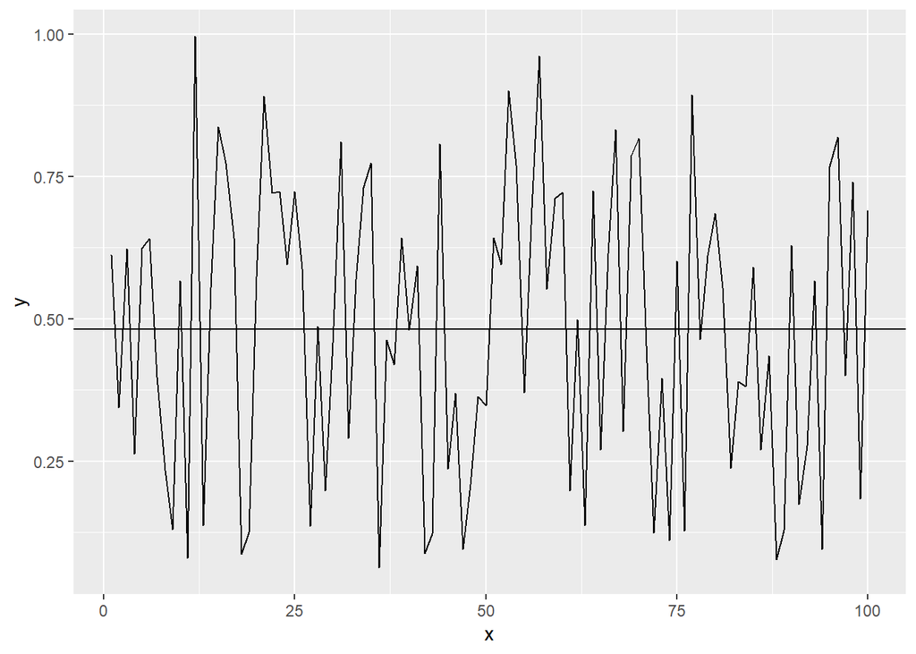

```r
gl <- ggplot(r, aes(x,y)) + geom_line()

# ggplot 이 담긴 변수에 옵션을 추가하면서 선을 그려 넣어본다.
gl + geom_hline(yintercept=mean(r$y))  # yintercept에 값을 넣음.
```

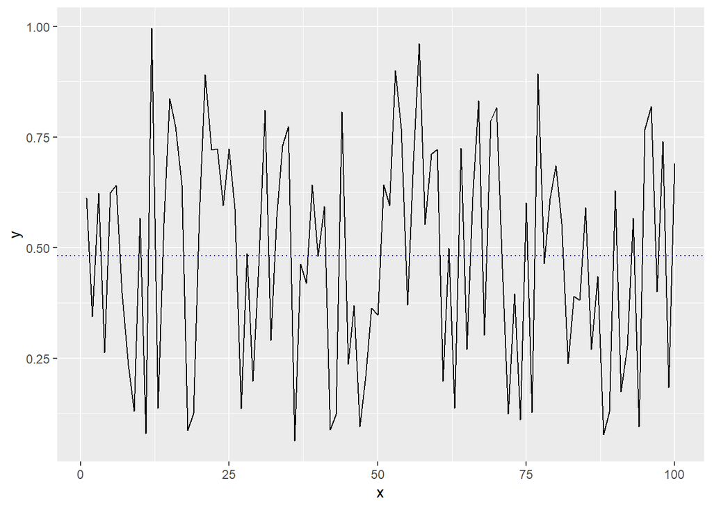

```r
# 수평선의 형태와 색을 변경한다.
gl + geom_hline(yintercept=mean(r$y), linetype="dotted", color = "blue")
```

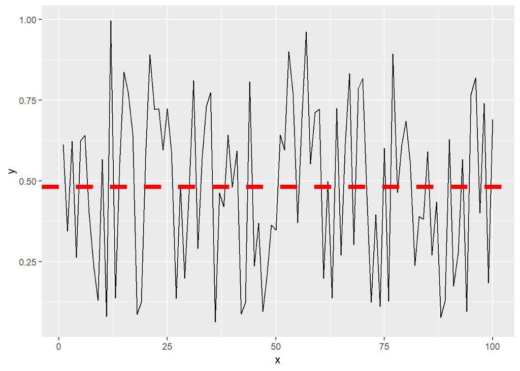

```r
# 수평선의 크기를 변경한다.
gl + geom_hline(yintercept=mean(r$y), linetype="dashed", color = "red", size=2)
```

**수직선은 + geom_vline() 를 활용한다.**